**Deep Learning for Mechanical Engineering**  
**Midterm Exam: Part II**  
**10/16/2023, 8:00 PM to 10:00 PM (120 minutes)**

Prof. Seungchul Lee  
http://iailab.kaist.ac.kr/  
Industrial AI Lab at KAIST

# Problem 1

(a) Suppose you have a dataset as depicted in the figure below. Can the perceptron algorithm classify this dataset?

- If yes, discuss how we can utilize the perceptron algorithm for this problem.
- If not, discuss the reasons behind the inability to employ the perceptron algorithm for this problem.

```python
import numpy as np
import matplotlib.pyplot as plt
import tensorflow as tf
%matplotlib inline
```

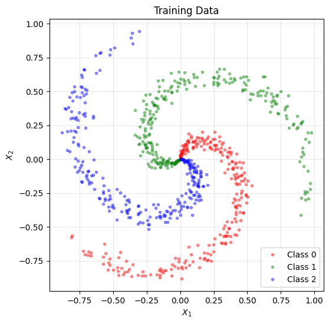

```python
# data generation (provided)

N = 250
n_class = 3

X, Y = [], []
r = np.linspace(0, 1, N)

for i in range(n_class):
    theta = np.linspace(4*i, 4*(i+1), N) + 0.2*np.random.randn(N)
    xp = np.array([r*np.sin(theta), r*np.cos(theta)])
    yp = i*np.ones(N)
    X.append(xp)
    Y.append(yp)

train_x = np.concatenate(X, axis = 1).T
train_y = np.concatenate(Y)

plt.figure(figsize = (6, 6))
plt.plot(train_x[train_y == 0,0], train_x[train_y == 0,1], 'r.', alpha = 0.4, label = 'Class 0')
plt.plot(train_x[train_y == 1,0], train_x[train_y == 1,1], 'g.', alpha = 0.4, label = 'Class 1')
plt.plot(train_x[train_y == 2,0], train_x[train_y == 2,1], 'b.', alpha = 0.4, label = 'Class 2')
plt.title('Training Data')
plt.legend(loc = 'lower right')
plt.xlabel('$X_1$')
plt.ylabel('$X_2$')
plt.grid(alpha = 0.3)
plt.show()
```

b) In this problem, we aim to construct an ANN model designed for tackling a multiclass non-linear classification problem.

```python
print(train_x.shape)
print(train_y.shape)
```

```
(750, 2)
(750,)
```

```python
model = tf.keras.models.Sequential([
    tf.keras.layers.Dense(units = 100, activation = 'relu', input_shape = (2,)),
    tf.keras.layers.Dense(units = 100, activation = 'relu'),
    tf.keras.layers.Dense(units = 3, activation = 'softmax')
])
```

```python
model.compile(optimizer = tf.keras.optimizers.Adam(0.001),
              loss = 'sparse_categorical_crossentropy',
              metrics = ['accuracy'])
```

```python
model.fit(train_x, train_y, epochs = 50, verbose = 0)
```

Let's evaluate the accuracy for a new test dataset.

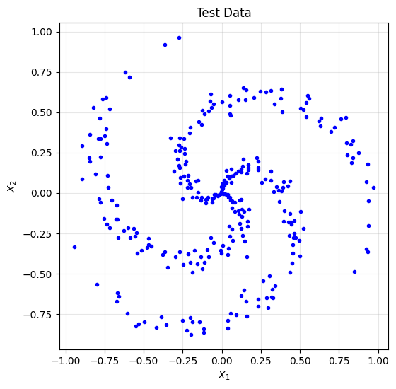

```python
## generate a new test dataset (provided)

m = 100
n_class = 3

X, Y = [], []
r = np.linspace(0, 1, m)

for i in range(n_class):
    theta = np.linspace(4*i, 4*(i+1), m) + 0.2*np.random.randn(m)
    xp = np.array([r*np.sin(theta), r*np.cos(theta)])
    yp = i*np.ones(m)
    X.append(xp)
    Y.append(yp)

test_x = np.concatenate(X, axis = 1).T
test_y = np.concatenate(Y)

plt.figure(figsize = (6, 6))
plt.title('Test Data')
plt.plot(test_x[test_y == 0,0], test_x[test_y == 0,1], 'b.')
plt.plot(test_x[test_y == 1,0], test_x[test_y == 1,1], 'b.')
plt.plot(test_x[test_y == 2,0], test_x[test_y == 2,1], 'b.')
plt.xlabel('$X_1$')
plt.ylabel('$X_2$')
plt.grid(alpha = 0.3)
plt.show()
```

c) Calculate accuracy for the test dataset and plot them with the predicted class.

```python
test_loss, test_acc = model.evaluate(test_x, test_y)
```

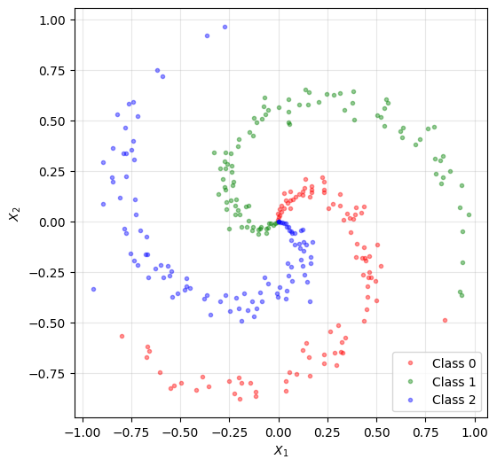

```python
predict = model.predict(test_x)
my_pred = np.argmax(predict, axis = 1)

plt.figure(figsize = (6, 6))
plt.plot(test_x[my_pred == 0,0], test_x[my_pred == 0,1], 'r.', alpha = 0.4, label = 'Class 0')
plt.plot(test_x[my_pred == 1,0], test_x[my_pred == 1,1], 'g.', alpha = 0.4, label = 'Class 1')
plt.plot(test_x[my_pred == 2,0], test_x[my_pred == 2,1], 'b.', alpha = 0.4, label = 'Class 2')
plt.legend(loc = 'lower right')
plt.xlabel('$X_1$')
plt.ylabel('$X_2$')
plt.grid(alpha = 0.3)
plt.show()
```

# Problem 2: Anomaly Detection with Autoencoder

Anomaly detection is a technique used to identify unusual patterns that do not conform to expected behavior, called outliers. Typically, this is treated as an unsupervised learning problem where the anomalous samples are not known a priori and it is assumed that the majority of the training dataset consists of "normal" data.

In the context of the MNIST dataset, let's consider digit 7 as representative of "normal" data. We will exclusively train an autoencoder using this "normal" data to enable the model to capture the features inherent to this normal data. As a result, it is reasonable to expect that when anomalous data is input into this trained autoencoder, the reconstruction performance will not be ideal. In other words, the reconstruction error, often referred to as the anomaly score, for anomalous data will likely be greater than that for normal data.

```python
import tensorflow as tf
import numpy as np
import matplotlib.pyplot as plt
```

```python
# Load Data

(train_imgs, train_labels), (test_imgs, test_labels) = tf.keras.datasets.mnist.load_data()
train_imgs, test_imgs = train_imgs.reshape(-1, 784)/255.0, test_imgs.reshape(-1, 784)/255.0
```

1) Designate digit 7 as representative of "normal" data. Extract all occurrences of digit 7 from `train_imgs` and `test_imgs`, creating new datasets named `normal_train_imgs` and `normal_test_imgs`, respectively.

```python
normal_train_imgs = train_imgs[np.where(train_labels == 7)]
normal_test_imgs = test_imgs[np.where(test_labels == 7)]
```

2) Design an autoencoder model and train it using the `normal_train_imgs` dataset.

```python
# Define Structure

# Encoder Structure
encoder = tf.keras.models.Sequential([
    tf.keras.layers.Dense(units = 500, activation = 'relu', input_shape = (784,)),
    tf.keras.layers.Dense(units = 300, activation = 'relu'),
    tf.keras.layers.Dense(units = 2, activation = None)
    ])

# Decoder Structure
decoder = tf.keras.models.Sequential([
    tf.keras.layers.Dense(units = 300, activation = 'relu', input_shape = (2,)),
    tf.keras.layers.Dense(units = 500, activation = 'relu'),
    tf.keras.layers.Dense(units = 28*28, activation = None)
    ])

# Autoencoder = Encoder + Decoder
autoencoder = tf.keras.models.Sequential([encoder, decoder])
```

```python
autoencoder.compile(optimizer = tf.keras.optimizers.Adam(0.001),
                    loss = 'mean_squared_error',)
```

```python
# Train Model & Evaluate Test Data

training = autoencoder.fit(normal_train_imgs, normal_train_imgs, batch_size = 50, epochs = 10)
```

3) Randomly select an image from `normal_test_imgs` and display its reconstructed image.

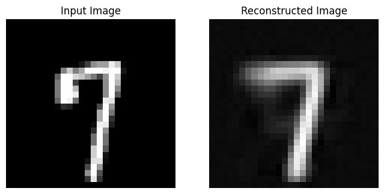

```python
idx = np.random.randint(normal_test_imgs.shape[0])
test_img = normal_test_imgs[idx]

reconst_img = autoencoder.predict(test_img.reshape(1, 28*28))

plt.figure(figsize = (8, 4))
plt.subplot(1,2,1)
plt.imshow(test_img.reshape(28,28), 'gray')
plt.title('Input Image', fontsize = 12)
plt.axis('off')
plt.subplot(1,2,2)
plt.imshow(reconst_img.reshape(28,28), 'gray')
plt.title('Reconstructed Image', fontsize = 12)
plt.axis('off')
plt.show()
```

4) Digit 5 will be considered as representative of "abnormal" data. Extract all digit 5 from `test_imgs` and create new datasets named `abnormal_test_imgs`.

```python
# Use digit 5 (treated as abnormal data)

abnormal_test_imgs = test_imgs[np.where(test_labels == 5)]
```

5) Randomly select one image from the `abnormal_test_imgs` dataset and display its reconstructed image.

- Note that the reconstruction performance is not as good as that of normal data. This is expected because the autoencoder was trained primarily on normal data, and its ability to reconstruct abnormal data is limited.

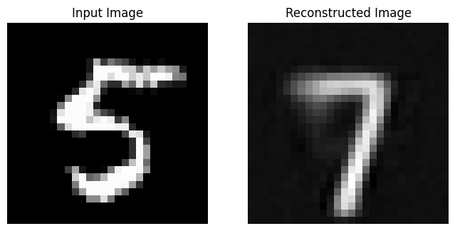

```python
idx = np.random.randint(abnormal_test_imgs.shape[0])
abnormal_test_img = abnormal_test_imgs[idx]

reconst_img = autoencoder.predict(abnormal_test_img.reshape(1, 28*28))

plt.figure(figsize = (8, 4))
plt.subplot(1,2,1)
plt.imshow(abnormal_test_img.reshape(28,28), 'gray')
plt.title('Input Image')
plt.axis('off')
plt.subplot(1,2,2)
plt.imshow(reconst_img.reshape(28,28), 'gray')
plt.title('Reconstructed Image')
plt.axis('off')
plt.show()
```

6) Compute and plot anomaly scores for the first 200 normal test images and the first 200 abnormal test images. To do this, you can calculate the reconstruction error (anomaly score) for each image and then create plots to visualize these scores. This will help you identify anomalies among the test images.

- Use the mean squared error as the anomaly score
- After computing the anomaly scores for both normal and abnormal test images, you can set a threshold to differentiate between normal and abnormal images based on the anomaly scores. The threshold will determine what level of anomaly score is considered "anomalous."
- Select a threshold value based on your visual inspection.

```python
normal_err = []
abnormal_err = []

for i in range(200):
    normal_img = normal_test_imgs[i].reshape(-1,784)
    normal_err.append(autoencoder.evaluate(normal_img, normal_img, verbose = 0))

    abnormal_img = abnormal_test_imgs[i].reshape(-1,784)
    abnormal_err.append(autoencoder.evaluate(abnormal_img, abnormal_img, verbose = 0))
```

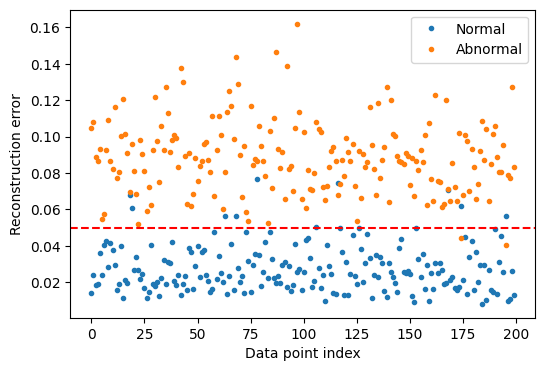

```python
threshold = 0.05

plt.figure(figsize = (6, 4))
plt.plot(normal_err, '.', label = 'Normal')
plt.plot(abnormal_err, '.', label = 'Abnormal')
plt.xlabel('Data point index')
plt.ylabel('Reconstruction error')
plt.axhline(y = threshold, color = 'r', linestyle='--')
plt.legend()
plt.show()
```

# Problem 3: Data Defect

**This problem is to demonstrate the importance of the class activation map**

Consider the following scenario: Professor Lee required a deep learning model capable of classifying the digits '7' and '9'. However, during the data collection process by Student A, an unforeseen malfunction occurred, affecting all the '9' digit images. Unfortunately, Student A was unaware of the defects in the collected data and proceeded to train the model with it. After training, the model achieved over 90% accuracy in binary classification using the validation dataset. Satisfied with the results, Student A handed over the model to Professor Lee.

Later, Professor Lee tested the model with his own dataset, which contained '9' digit images without any defects. To his surprise, the model's test accuracy was significantly lower. This situation occurred because Student A had not generated class activation maps for the validation dataset. It was crucial for Student A to examine the areas in which the model focused when making classification decisions.

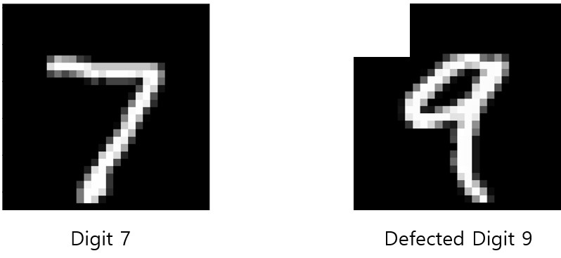

1) Load the dataset provided below

- Download [MNIST_defected_imgs.npy](https://drive.google.com/file/d/1U04yuKizfB05zbAZAq7lZaz9WUbb10lz/view?usp=sharing)
- Download [MNIST_defected_labels.npy](https://drive.google.com/file/d/1k-PYHkpD-AI5xAgO1SrKGWzH1rXzI9VD/view?usp=sharing)

```python
import numpy as np
import matplotlib.pyplot as plt
import tensorflow as tf
from sklearn.model_selection import train_test_split
import os
import cv2
```

```python
from google.colab import drive
drive.mount('/content/drive')
```

```python
images = np.load('/content/drive/MyDrive/DL_Colab/DL_data/MNIST_defected_imgs.npy')
labels = np.load('/content/drive/MyDrive/DL_Colab/DL_data/MNIST_defected_labels.npy')
```

```python
defected_train_imgs, defected_test_imgs, defected_train_labels, defected_test_labels = train_test_split(images, labels, test_size = 0.2, random_state = 0)
```

```python
print(defected_train_imgs.shape)
print(defected_train_labels.shape)
print(defected_test_imgs.shape)
print(defected_test_labels.shape)
```

```
(9771, 28, 28, 1)
(9771,)
(2443, 28, 28, 1)
(2443,)
```

2) Manually select digit 7 and digit 9, and plot them.

- Note that only digit 9 is defected as shown below.

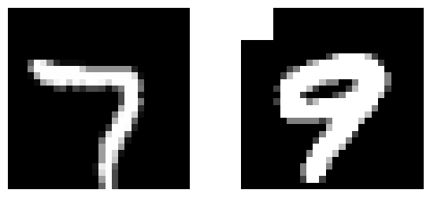

```python
defected_img7 = defected_train_imgs[1000,...]
defected_img9 = defected_train_imgs[9000,...]

plt.figure(figsize = (7, 3))
plt.subplot(1,2,1)
plt.imshow(defected_img7.reshape(28,28), 'gray')
plt.axis('off')
plt.subplot(1,2,2)
plt.imshow(defected_img9.reshape(28,28), 'gray')
plt.axis('off')
plt.show()
```

3) Design your CNN structure for the binary classification and train your model.

```python
model = tf.keras.models.Sequential([
    tf.keras.layers.Conv2D(filters = 32,
                           kernel_size = (3,3),
                           activation = 'relu',
                           padding = 'SAME',
                           input_shape = (28, 28, 1)),

    tf.keras.layers.MaxPool2D((2,2)),

    tf.keras.layers.Conv2D(filters = 64,
                           kernel_size = (3,3),
                           activation = 'relu',
                           padding = 'SAME',
                           input_shape = (14, 14, 32)),

    tf.keras.layers.MaxPool2D((2,2)),

    tf.keras.layers.Conv2D(filters = 128,
                        kernel_size = (3,3),
                        activation = 'relu',
                        padding = 'SAME',
                        input_shape = (7, 7, 64)),

    tf.keras.layers.MaxPool2D((2,2)),

    tf.keras.layers.Flatten(),

    tf.keras.layers.Dense(units = 128, activation = 'relu'),

    tf.keras.layers.Dense(units = 2, activation = 'softmax')
])

model.summary()
```

```
Model: "sequential_6"
_________________________________________________________________
 Layer (type)                Output Shape              Param #
=================================================================
 conv2d_6 (Conv2D)           (None, 28, 28, 32)        320

 max_pooling2d_5 (MaxPoolin  (None, 14, 14, 32)        0
 g2D)

 conv2d_7 (Conv2D)           (None, 14, 14, 64)        18496

 max_pooling2d_6 (MaxPoolin  (None, 7, 7, 64)          0
 g2D)

 conv2d_8 (Conv2D)           (None, 7, 7, 128)         73856

 max_pooling2d_7 (MaxPoolin  (None, 3, 3, 128)         0
 g2D)

 flatten_1 (Flatten)         (None, 1152)              0

 dense_12 (Dense)            (None, 128)               147584

 dense_13 (Dense)            (None, 2)                 258

=================================================================
Total params: 240514 (939.51 KB)
Trainable params: 240514 (939.51 KB)
Non-trainable params: 0 (0.00 Byte)
_________________________________________________________________
```

```python
model.compile(optimizer = tf.keras.optimizers.Adam(0.001),
              loss = 'sparse_categorical_crossentropy',
              metrics = ['accuracy'])
```

```python
model.fit(defected_train_imgs, defected_train_labels, epochs = 10)
```

```
<keras.src.callbacks.History at 0x7c577cbe0ca0>
```

4) Report the test accuary.

```python
model.evaluate(defected_test_imgs, defected_test_labels)
```

```
[3.6597165298246637e-09, 1.0]
```

5) With the test dataset provided below, report the test accuracy of your trained model.

- Download [MNIST_undefected_test_imgs.npy](https://drive.google.com/file/d/1o53_xR_TaM761Ti1t4R5iNW1UsTt6p_i/view?usp=sharing)
- Download [MNIST_undefected_test_labels.npy](https://drive.google.com/file/d/1ARjsW1F5W5hKiM8hVUdoSecc7EPbEqwZ/view?usp=sharing)
- Test accuracy is supposed to be low! Do not worry.

```python
undefected_test_imgs = np.load('/content/drive/MyDrive/DL_Colab/DL_data/MNIST_undefected_test_imgs.npy')
undefected_test_labels = np.load('/content/drive/MyDrive/DL_Colab/DL_data/MNIST_undefected_test_labels.npy')
```

```python
print(undefected_test_imgs.shape)
print(undefected_test_labels.shape)
```

```
(1222, 28, 28, 1)
(1222,)
```

```python
model.evaluate(undefected_test_imgs, undefected_test_labels)
```

```
[9.15645694732666, 0.512274980545044]
```

6) Manually select digit 7 and digit 9 from `undefected_test_imgs`, and plot them to understand why the trained model's accuracy is too low with the given test dataset.

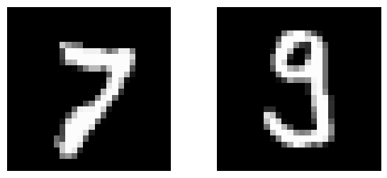

```python
undefected_img7 = undefected_test_imgs[1,...]
undefected_img9 = undefected_test_imgs[200,...]

plt.figure(figsize = (7, 3))
plt.subplot(1,2,1)
plt.imshow(undefected_img7.reshape(28,28), 'gray')
plt.axis('off')
plt.subplot(1,2,2)
plt.imshow(undefected_img9.reshape(28,28), 'gray')
plt.axis('off')
plt.show()
```

7) Build Class Activation Map (CAM) model to visualize the region where the trained model focuses for the defected train dataset.

- Plot class activation maps for the defected digit 9 from the test dateset
- By plotting the class activation maps, you should be able to find the defects within the training data
- Train it with `defected_train_imgs`

```python
CAM_model = tf.keras.models.Sequential([
    tf.keras.layers.Conv2D(filters = 32,
                           kernel_size = (3,3),
                           activation = 'relu',
                           padding = 'SAME',
                           input_shape = (28, 28, 1)),

    tf.keras.layers.MaxPool2D((2,2)),

    tf.keras.layers.Conv2D(filters = 64,
                           kernel_size = (3,3),
                           activation = 'relu',
                           padding = 'SAME',
                           input_shape = (14, 14, 32)),

    tf.keras.layers.MaxPool2D((2,2)),

    tf.keras.layers.Conv2D(filters = 128,
                        kernel_size = (3,3),
                        activation = 'relu',
                        padding = 'SAME',
                        input_shape = (7, 7, 64)),

    tf.keras.layers.GlobalAveragePooling2D(),

    tf.keras.layers.Dense(units = 2, activation = 'softmax')
])
```

```python
CAM_model.compile(optimizer = tf.keras.optimizers.Adam(0.001),
                  loss = 'sparse_categorical_crossentropy',
                  metrics = ['accuracy'])

CAM_model.fit(defected_train_imgs, defected_train_labels, epochs = 10)
```

```
<keras.src.callbacks.History at 0x7c57761c7970>
```

```python
conv_layer = CAM_model.get_layer(index = 4)
fc_layer = CAM_model.layers[6].get_weights()[0]

my_map = tf.matmul(conv_layer.output, fc_layer)
CAM = tf.keras.Model(inputs = CAM_model.inputs, outputs = my_map)
```

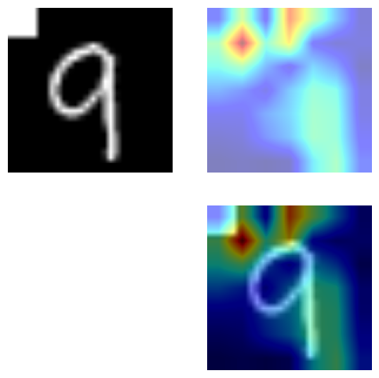

```python
idx = 28
test_image = defected_test_imgs[[idx]]

pred = np.argmax(CAM_model.predict(test_image), axis = 1)
predCAM = CAM.predict(test_image)

attention = predCAM[:,:,:,pred]
attention = np.abs(np.reshape(attention,(7,7)))

large_test_x = cv2.resize(test_image.reshape(28,28), (28*5, 28*5))
large_attention = cv2.resize(attention, (28*5, 28*5))

plt.figure(figsize = (6, 6))
plt.subplot(2,2,1)
plt.imshow(large_test_x, 'gray')
plt.axis('off')
plt.subplot(2,2,2)
plt.imshow(large_attention, 'jet', alpha = 0.5)
plt.axis('off')
plt.subplot(2,2,4)
plt.imshow(large_test_x, 'gray')
plt.imshow(large_attention, 'jet', alpha = 0.5)
plt.axis('off')
plt.show()
```

8) With the information of the defects obtained in the subproblem 7), fix the defects within the training data

- Hint 1: Change the pixel value of the defected region
- Hint 2: The defected region exists in only one of two classes and the locations of such defects are the same in all defected images
- Hint 3: Defect locations in the image matrix: (0,0), (0,1), (0,2), (0,3), (0,4), (1,0), (1,1), (1,2), (1,3), (1,4),(2,0), (2,1), (2,2), (2,3), (2,4), (3,0), (3,1), (3,2), (3,3), (3,4), (4,0), (4,1), (4,2), (4,3), (4,4)
- Hint 4: Set these pixel value to 0

```python
defected_train_imgs[np.where(defected_train_labels == 1), 0:5, 0:5] = 0
```

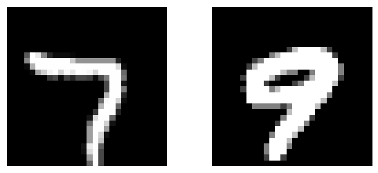

```python
defected_img7 = defected_train_imgs[1000,...]
defected_img9 = defected_train_imgs[9000,...]

plt.figure(figsize = (7, 3))
plt.subplot(1,2,1)
plt.imshow(defected_img7.reshape(28,28), 'gray')
plt.axis('off')
plt.subplot(1,2,2)
plt.imshow(defected_img9.reshape(28,28), 'gray')
plt.axis('off')
plt.show()
```

9) With the corrected training dataset obtained in subproblem 8), re-train the model you defined in subproblem 3) and report the test accuracy for the test dataset (`undefected_test_imgs`).

```python
model.fit(defected_train_imgs, defected_train_labels, epochs = 10)
```

```
<keras.src.callbacks.History at 0x7c57bc5039d0>
```

```python
model.evaluate(undefected_test_imgs, undefected_test_labels)
```

```
[0.0008377390913665295, 0.9991816878318787]
```